# Taiwan Vote Project in R Shiny

## Part 2: Correlation Plots

Next I looked at each party individually and the correlation between the different district-wide variables.

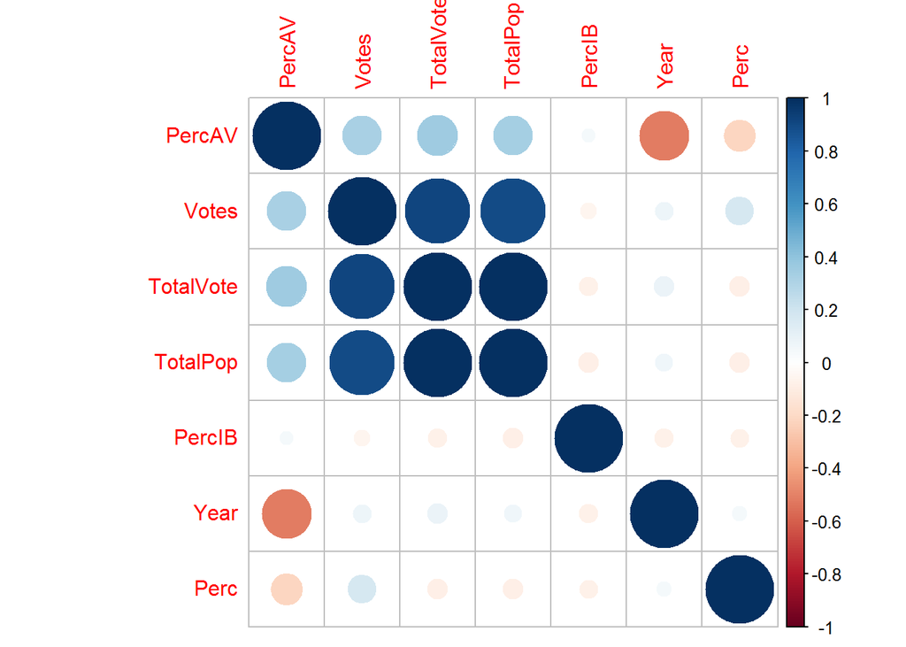

```r
library(corrplot)
loc = partylines[partylines$ANameE != "National",]
kmt = loc[loc$Party=="KMT",]
corrplot(cor(kmt[c(-1,-4)]), order="hclust")
```

There seems to be a negative correlation between Year and PercAV, meaning that there is a decreasing amount of people actually voting! It seems logical that there is a correlation between votes, totalvote, and totalpop. The more people there are, the more votes there are.

For DPP there seems to be more positive correlation between the variables as there are more blue circles in the chart, especially in regards to the correlation of other values to Perc (percent of votes recieved).

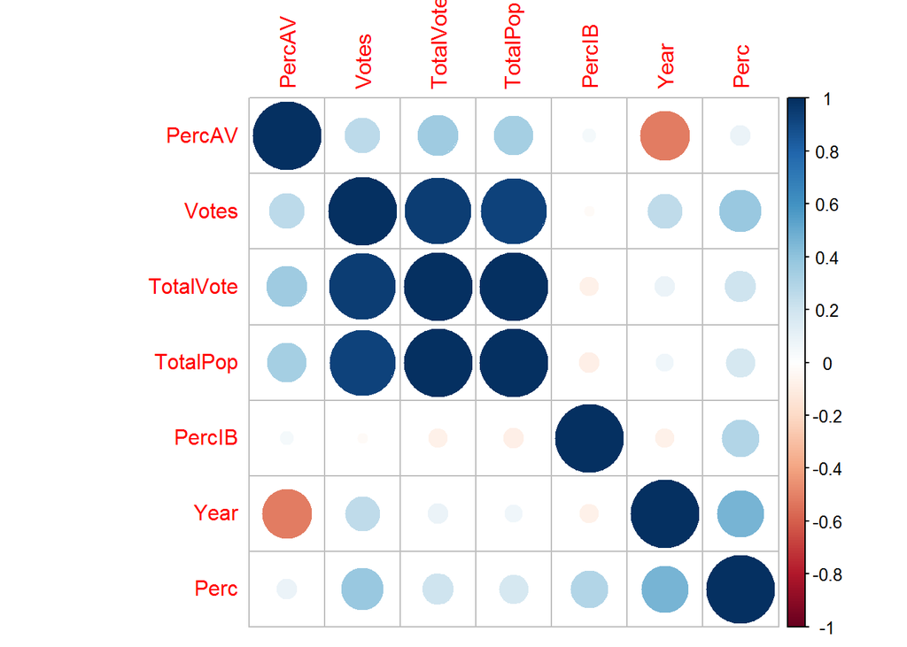

```r
dpp = loc[loc$Party=="DPP",]
corrplot(cor(dpp[c(-1,-4)]), order="hclust")
```

## Part 3: Box Plots

Next I looked at side-by-side boxplots of all the election data for districts that voted for KMT.

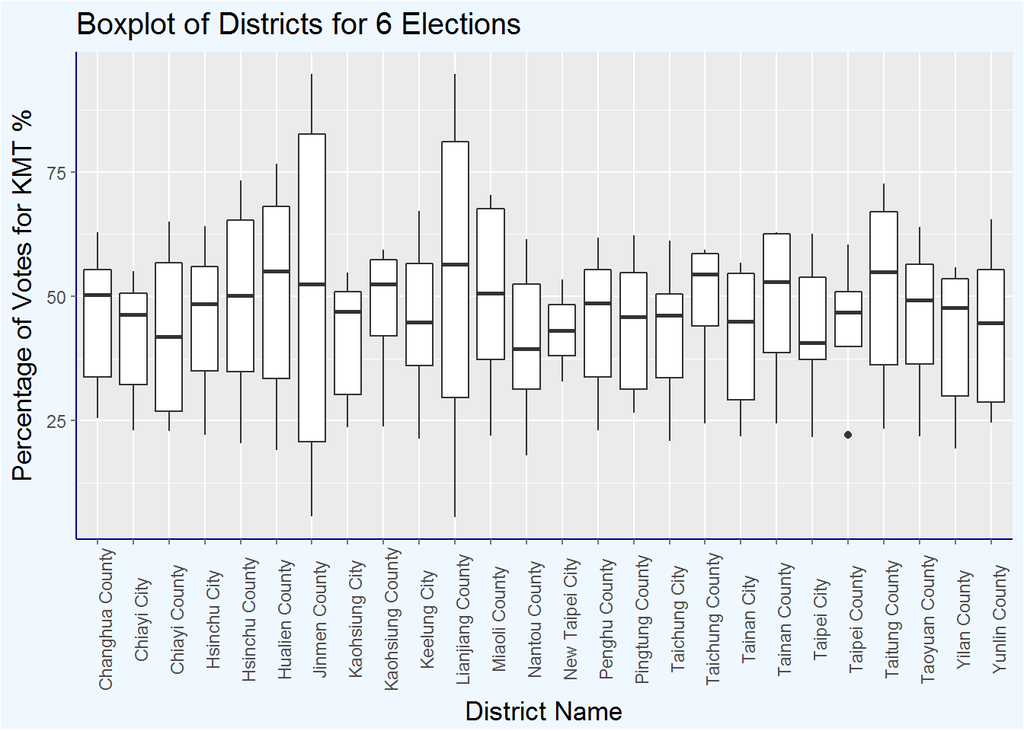

```r
library(ggplot2)
par(mfrow=c(1,1))
ggplot(kmt, aes(x = kmt$ANameE, y = kmt$Perc)) +
  geom_boxplot() + theme(plot.subtitle = element_text(vjust = 1),
                         plot.caption = element_text(vjust = 1),
                         axis.line = element_line(colour = "blue4",
                                                  linetype = "solid"), axis.ticks =
                           element_line(colour = "gray46"),
                         axis.title = element_text(size = 13),
                         axis.text.x = element_text(angle = 90),
                         plot.title = element_text(size = 15),
                         plot.background = element_rect(fill = "aliceblue")) +
  labs(title = "Boxplot of Districts for 6 Elections",
  x = "District Name", y = "Percentage of Votes for KMT %")
```

and performed a Bartlett test of homogeneity of variances and a One-Way ANOVA test to assess the equality of means of two or more groups:

```r
bartlett.test(kmt$Perc~kmt$ANameE) #p-value = 0.7864
```

```
##
##  Bartlett test of homogeneity of variances
##
## data:  kmt$Perc by kmt$ANameE
## Bartlett's K-squared = 19.22, df = 25, p-value = 0.7864
```

```r
summary(aov(kmt$Perc~kmt$ANameE))
```

```
##              Df Sum Sq Mean Sq F value Pr(>F)
## kmt$ANameE   25   1925      77   0.206      1
## Residuals   118  44014     373
```

The p-value for the ANOVA is 1, which means we have insufficient evidence to conclude that the percent vote of districts differ in any significant way. The Bartlett test confirmed that the variances are equal across groups (the districts that voted KMT).

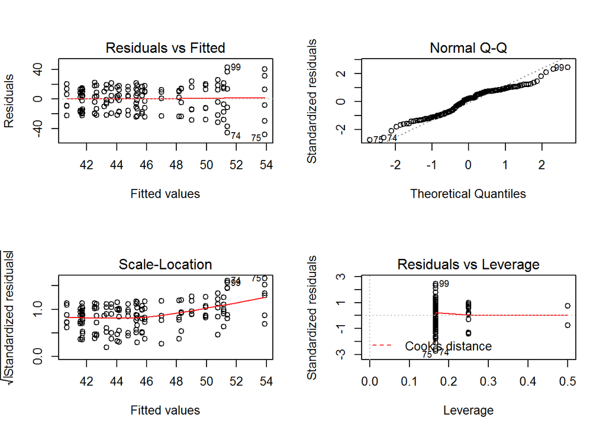

```r
par(mfrow=c(2,2))
plot(aov(kmt$Perc~kmt$ANameE))
```

For the DPP the boxplot looks as such:

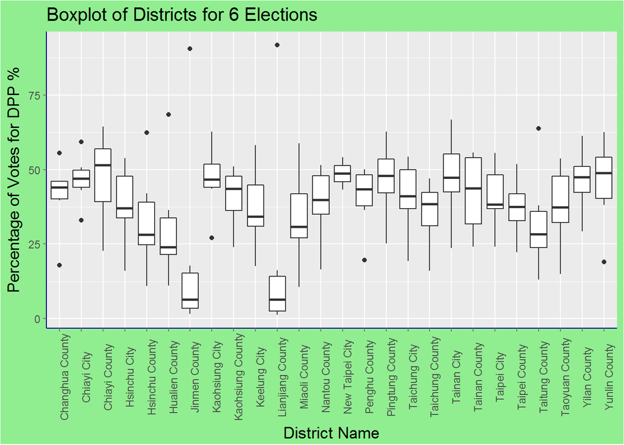

```r
par(mfrow=c(1,1))
ggplot(kmt, aes(x = dpp$ANameE, y = dpp$Perc)) +
  geom_boxplot() + theme(plot.subtitle = element_text(vjust = 1),
                         plot.caption = element_text(vjust = 1),
                         axis.line = element_line(colour = "blue4",
                                                  linetype = "solid"), axis.ticks =
                           element_line(colour = "gray46"),
                         axis.title = element_text(size = 13),
                         axis.text.x = element_text(angle = 90),
                         plot.title = element_text(size = 15),
                         plot.background = element_rect(fill = "lightgreen")) +
  labs(title = "Boxplot of Districts for 6 Elections",
  x = "District Name", y = "Percentage of Votes for DPP %")
```

```r
#the boxplots do look less orderly, so I performed a Bartlett test and a One-Way ANOVA test again:
bartlett.test(dpp$Perc~dpp$ANameE) #p-value = 0.2114
```

```
##
##  Bartlett test of homogeneity of variances
##
## data:  dpp$Perc by dpp$ANameE
## Bartlett's K-squared = 30.352, df = 25, p-value = 0.2114
```

```r
summary(aov(dpp$Perc~dpp$ANameE))
```

```
##              Df Sum Sq Mean Sq F value Pr(>F)
## dpp$ANameE   25   7890   315.6   1.118  0.334
## Residuals   118  33309   282.3
```

The ANOVA test came back with a p-value of 0.334, which although less, is still insufficient to conclude that the percent vote of districts differ in any significant way. The p-value for the Bartlett test is 0.2114 which confirms that the variances are equal across the % of people in districts that voted for the DPP.

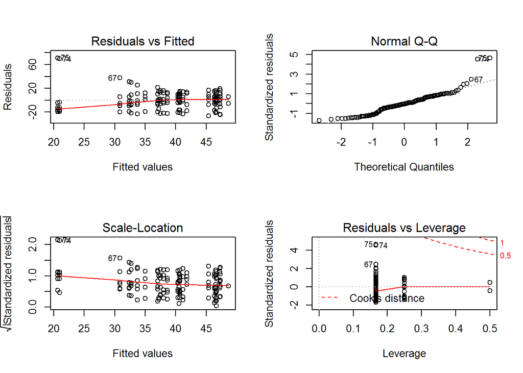

```r
par(mfrow=c(2,2))
plot(aov(dpp$Perc~dpp$ANameE))
```

## Part 4: Chi-Squared test and Chi-Squared Residuals Plot

Finally, I did the Chi-squared test which evaluates whether there is a significant association between the categories of two variables (district and year): #Null hypothesis (H0): the row and the column variables of the contingency table are independent. #Alternative hypothesis (H1): row and column variables are dependent

```r
library(tidyr)
kmtchisqdata = kmt[c(-3,-4,-5,-7,-8,-9)]
kmtchisqdata = spread(data = kmtchisqdata, key = ANameE, value = Perc)
#Next, because some districts were renamed in 2012, we need to fill in some missing data:
kmtchisqdata[10][5:6,]= kmtchisqdata[9][5:6,]
kmtchisqdata[15][1:4,]= kmtchisqdata[23][1:4,]
kmtchisqdata[23][5:6,]= kmtchisqdata[15][5:6,]
kmtchisqdata[19][5:6,]= kmtchisqdata[18][5:6,]
kmtchisqdata[21][5:6,]= kmtchisqdata[20][5:6,]
kmtchisqdata = kmtchisqdata[-23] #Taipei County renamed to New Taipei City

chisq = chisq.test(kmtchisqdata[-1])
chisq
```

```
##
##  Pearson's Chi-squared test
##
## data:  kmtchisqdata[-1]
## X-squared = 347.42, df = 120, p-value < 2.2e-16
```

With a p-value < 2.2e-16, we can reject the null hypothesis and conclude that votes by district and votes by year are dependent.

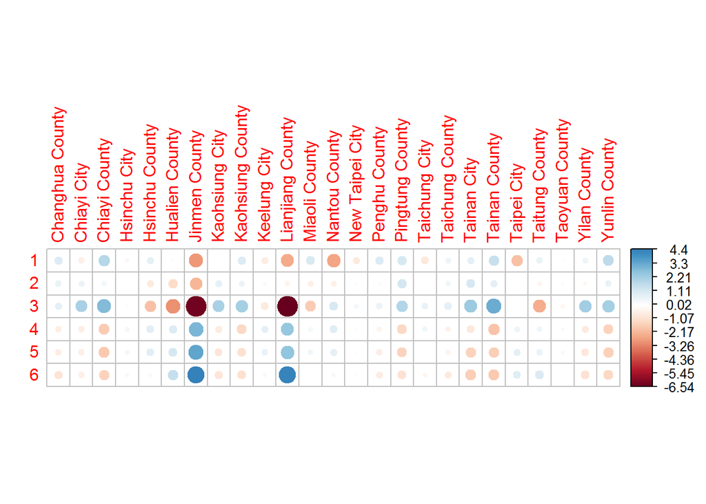

```r
library(corrplot)
par(mfrow=c(1,1))
corrplot(chisq$residuals, is.cor = FALSE)
```

Here are the results of the Chi-squared test for the DPP:

```r
dppchisqdata = dpp[c(-3,-4,-5,-7,-8,-9)]
dppchisqdata = spread(data = dppchisqdata, key = ANameE, value = Perc)
dppchisqdata[10][5:6,]= dppchisqdata[9][5:6,]
dppchisqdata[15][1:4,]= dppchisqdata[23][1:4,]
dppchisqdata[23][5:6,]= dppchisqdata[15][5:6,]
dppchisqdata[19][5:6,]= dppchisqdata[18][5:6,]
dppchisqdata[21][5:6,]= dppchisqdata[20][5:6,]
dppchisqdata = dppchisqdata[-23]

chisq2 = chisq.test(dppchisqdata[-1])
chisq2
```

```
##
##  Pearson's Chi-squared test
##
## data:  dppchisqdata[-1]
## X-squared = 556.16, df = 120, p-value < 2.2e-16
```

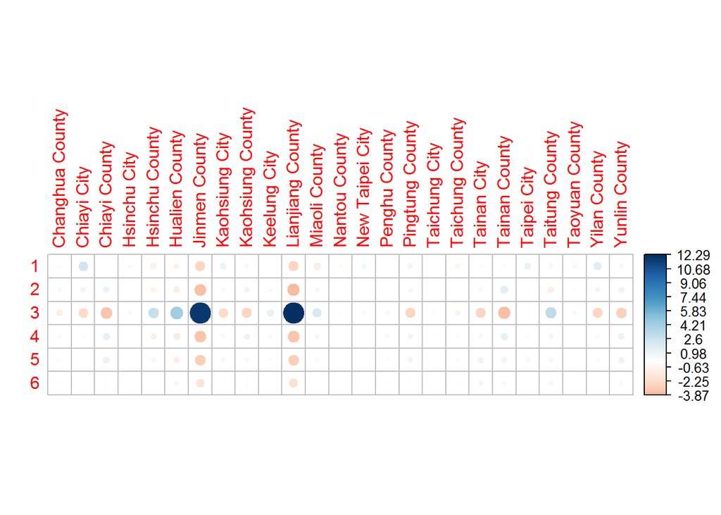

```r
#With a p-value < 2.2e-16, we can reject the null hypothesis and conclude that votes by district and votes by year are dependent.
par(mfrow=c(1,1))
corrplot(chisq2$residuals, is.cor = FALSE)
```